# Regresion Lineal

Juliana M. Huertas M.

## **Introducción**

El análisis de la regresión lineal se utiliza para predecir el valor de una variable según el valor de otra. La variable que desea predecir se denomina variable dependiente. La variable que está utilizando para predecir el valor de la otra variable se denomina variable independiente.

Esta forma de análisis estima los coeficientes de la ecuación lineal, involucrando una o a más variables independientes que mejor predicen el valor de la variable dependiente. La regresión lineal se ajusta a una línea recta o a una superficie que minimiza las discrepancias entre los valores de salida previstos y reales.

La regresión lineal se utiliza en todo, desde las ciencias biológicas, conductuales, ambientales y sociales hasta en los negocios. Los modelos de regresión lineal se han convertido en una forma comprobada de predecir el futuro de forma científica y confiable.

Una forma general de expresar el modelo es la siguiente:

$$ Y=\beta_{0}+\beta_{1} X_{1}+\cdots+\beta_{m} X_{m}+\varepsilon $$$$ =\beta_{0}+\sum_{j=1}^{m} \beta_{j} X_{j}+\varepsilon $$

donde:

- $Y$ es la variable dependiente o variable de respuesta.
- $X_{1}, X_{2}, \ldots, X_{n 2}$ son las variables explicativas, independientes o regresoras.
- $\beta_{0}, \beta_{1}, \beta_{2}, \ldots, \beta_{m}$ son los parámetros del modelo, miden la influencia que las variables explicativas tienen sobre el regrediendo.

[figure not shown]

Fuente: [RegresionLinealIBM](https://www.ibm.com/co-es/analytics/learn/linear-regression)

## **Historia**

La primera forma de regresión lineal documentada fue el método de los mínimos cuadrados que fue publicada por Legendre en 1805, Gauss publicó un trabajo en donde desarrollaba de manera más profunda el método de los mínimos cuadrados, y en dónde se incluía una versión del teorema de Gauss-Márkov.

El término regresión se utilizó por primera vez en el estudio de variables antropométricas: al comparar la estatura de padres e hijos, donde resultó que los hijos cuyos padres tenían una estatura muy superior al valor medio, tendían a igualarse a este, mientras que aquellos cuyos padres eran muy bajos tendían a reducir su diferencia respecto a la estatura media; es decir, "regresaban" al promedio. La constatación empírica de esta propiedad se vio reforzada más tarde con la justificación teórica de ese fenómeno.

El término lineal se emplea para distinguirlo del resto de técnicas de regresión, que emplean modelos basados en cualquier clase de función matemática. Los modelos lineales son una explicación simplificada de la realidad, mucho más ágiles y con un soporte teórico mucho más extenso por parte de la matemática y la estadística.

Fuente: [RegresionLinealWiki](https://es.wikipedia.org/wiki/Regresi%C3%B3n_lineal)

[figure not shown]

## **Algoritmo**

Computacionalmente, estos cálculos son más eficientes si se realizan de forma matricial:

$$ \begin{array}{c} \mathbf{y}=\mathbf{X}^{T} \beta+\epsilon \\ \mathbf{y}=\left[\begin{array}{c} y_{1} \\ y_{2} \\ \ldots \\ y_{n} \end{array}\right], \quad \mathbf{X}=\left[\begin{array}{cccc} 1 & x_{11} & \ldots & x_{1 p} \\ 1 & x_{21} & \ldots & x_{2 p} \\ 1 & \ldots & \ldots & \ldots \\ 1 & x_{n 1} & \ldots & x_{n p} \end{array}\right], \quad \beta=\left[\begin{array}{c} \beta_{0} \\ \beta_{1} \\ \ldots \\ \beta_{n} \end{array}\right], \quad \epsilon=\left[\begin{array}{c} \epsilon_{1} \\ \epsilon_{2} \\ \ldots \\ \epsilon_{n} \end{array}\right] \\ \hat{\beta}=\underset{\beta}{\arg \min }\left(\mathbf{y}-\mathbf{X}^{T} \beta\right)^{2} \end{array} $$

Una vez estimados los coeficientes, se pueden obtener las estimaciones de cada observación $\left(\hat{y}_{i}\right): $

$$ \hat{y}_{i}=\hat{\beta}_{0}+\hat{\beta}_{1} x_{i 1}+\hat{\beta}_{2} x_{i 2}+\ldots+\hat{\beta}_{p} x_{i p} $$

Finalmente, la estimación de la varianza del modelo $\left(\hat{\sigma}^{2}\right)$ se obtiene como:

$$ \hat{\sigma}^{2}=\frac{\sum_{i=1}^{n} \hat{\epsilon}_{i}^{2}}{n-p}=\frac{\sum_{i=1}^{n}\left(y_{i}-\hat{y}_{i}\right)^{2}}{n-p} $$

donde $n$ es el número de observaciones y $p$ el número de predictores.

Fuente:[Algoritmo Regresión](https://www.cienciadedatos.net/documentos/py10-regresion-lineal-python.html)

## **Aplicación**

### **Conjunto de datos**

El conjunto de datos que se utilizó para la implementación de la regresión lineal simple tiene dos variables:

**Implicito** : Precio de un determinado commodity en Colombia

**Internacional** : Precio del mismo commodity pero en mercado internacional

El objetivo aquí es observar si precio del commodity en el mercado internacional influye en el precio del commodity en Colombia, y si es así en que sentido lo afecta.

```python
#librerias
import numpy as np
import pandas as pd
from sklearn.model_selection import train_test_split
from scipy.stats import pearsonr
from sklearn.linear_model import LinearRegression
from sklearn.model_selection import train_test_split
from sklearn.metrics import r2_score
from sklearn.metrics import mean_squared_error
import statsmodels.api as sm
import statsmodels.formula.api as smf
```

```python
df=pd.read_excel("Base_Ejemplo.xlsx")
df.head()
```

|  | Implicito | Internacional |
| --- | --- | --- |
| 0 | 2.413264 | 6.929847 |
| 1 | 2.764594 | 7.214243 |
| 2 | 2.520347 | 6.511281 |
| 3 | 2.087022 | 5.778767 |
| 4 | 2.327417 | 6.787122 |

```python
#VARIABLE INDEPENDIENTE X=INTERNACIONAL
X=df.iloc[:,1]
#VARIABLE DEPENDIENTE Y=IMPLICITO
Y=df.iloc[:,0]
```

### **Implementación**

Para la implementación de la regresión en Python se utiliza **sklearn** y **stats**

## Sklearn

```python
from sklearn.linear_model import LinearRegression

X_train, X_test, y_train, y_test = train_test_split(X.values.reshape(-1,1),
                                                    Y.values.reshape(-1,1),
                                                    train_size   = 0.8,
                                                    random_state = 1997)
```

```python
linreg = LinearRegression().fit(X_train, y_train)

print('linear model coeff (w): {}'
     .format(linreg.coef_))
print('linear model intercept (b): {}'
     .format(linreg.intercept_))
print('R-squared score (training): {:.3f}'
     .format(linreg.score(X_train, y_train)))
print('R-squared score (test): {:.3f}'
     .format(linreg.score(X_test, y_test)))
```

```
linear model coeff (w): [[0.33747361]]
linear model intercept (b): [-0.16377436]
R-squared score (training): 0.924
R-squared score (test): 0.884
```

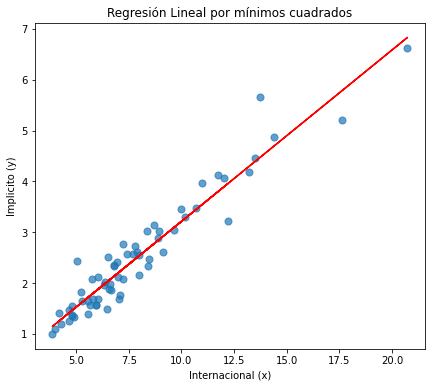

```python
import matplotlib.pyplot as plt
plt.figure(figsize=(7,6))
plt.scatter(X, Y, marker= 'o', s=50, alpha=0.7)
plt.plot(X.values.reshape(-1,1), linreg.coef_ * X.values.reshape(-1,1) + linreg.intercept_, 'r-')
plt.title('Regresión Lineal por mínimos cuadrados')
plt.xlabel('Internacional (x)')
plt.ylabel('Implicito (y)')
plt.show()
```

## Stats

La implementación de regresión lineal de Statsmodels, es más completa que la de Scikitlearn ya que, además de ajustar el modelo, permite calcular los test estadísticos y análisis necesarios para verificar que se cumplen las condiciones sobre las que se basa este tipo de modelos

```python
X_train = sm.add_constant(X_train, prepend=True)
modelo = sm.OLS(endog=y_train, exog=X_train,)
modelo = modelo.fit()
print(modelo.summary())
```

```
                            OLS Regression Results
==============================================================================
Dep. Variable:                      y   R-squared:                       0.924
Model:                            OLS   Adj. R-squared:                  0.923
Method:                 Least Squares   F-statistic:                     599.4
Date:                Fri, 12 Mar 2021   Prob (F-statistic):           3.89e-29
Time:                        15:39:45   Log-Likelihood:                -16.723
No. Observations:                  51   AIC:                             37.45
Df Residuals:                      49   BIC:                             41.31
Df Model:                           1
Covariance Type:            nonrobust
==============================================================================
                 coef    std err          t      P>|t|      [0.025      0.975]
------------------------------------------------------------------------------
const         -0.1638      0.122     -1.348      0.184      -0.408       0.080
x1             0.3375      0.014     24.484      0.000       0.310       0.365
==============================================================================
Omnibus:                       13.022   Durbin-Watson:                   2.108
Prob(Omnibus):                  0.001   Jarque-Bera (JB):               16.673
Skew:                           0.888   Prob(JB):                     0.000240
Kurtosis:                       5.167   Cond. No.                         22.6
==============================================================================

Warnings:
[1] Standard Errors assume that the covariance matrix of the errors is correctly specified.
```

### Intervalos de confianza

```python
modelo.conf_int(alpha=0.05)
```

```
array([[-0.40800984,  0.08046111],
       [ 0.30977437,  0.36517285]])
```

### Predicciones

```python
predicciones = modelo.get_prediction(exog = X_train).summary_frame(alpha=0.05)
predicciones.head(4)
```

|  | mean | mean_se | mean_ci_lower | mean_ci_upper | obs_ci_lower | obs_ci_upper |
| --- | --- | --- | --- | --- | --- | --- |
| 0 | 3.958250 | 0.074272 | 3.808994 | 4.107506 | 3.253677 | 4.662823 |
| 1 | 2.086891 | 0.051882 | 1.982630 | 2.191152 | 1.390460 | 2.783322 |
| 2 | 2.671028 | 0.048157 | 2.574253 | 2.767804 | 1.975679 | 3.366378 |
| 3 | 1.538203 | 0.063865 | 1.409863 | 1.666544 | 0.837763 | 2.238644 |

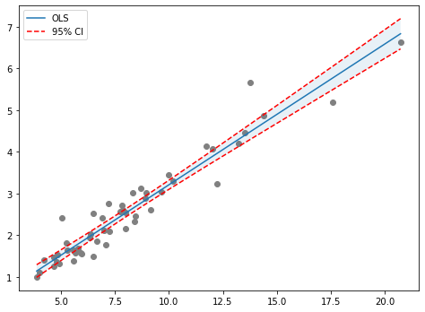

```python
predicciones = modelo.get_prediction(exog = X_train).summary_frame(alpha=0.05)
predicciones['x'] = X_train[:, 1]
predicciones['y'] = y_train
predicciones = predicciones.sort_values('x')

# Gráfico del modelo
# ==============================================================================
fig, ax = plt.subplots(figsize=(8, 5.84))

ax.scatter(predicciones['x'], predicciones['y'], marker='o', color = "gray")
ax.plot(predicciones['x'], predicciones["mean"], linestyle='-', label="OLS")
ax.plot(predicciones['x'], predicciones["mean_ci_lower"], linestyle='--', color='red', label="95% CI")
ax.plot(predicciones['x'], predicciones["mean_ci_upper"], linestyle='--', color='red')
ax.fill_between(predicciones['x'], predicciones["mean_ci_lower"], predicciones["mean_ci_upper"], alpha=0.1)
ax.legend();
```

```python
#Error del test
X_test = sm.add_constant(X_test, prepend=True)
predicciones = modelo.predict(exog = X_test)
rmse = mean_squared_error(
        y_true  = y_test,
        y_pred  = predicciones,
        squared = False
       )
print("")
print(f"El error (rmse) de test es: {rmse}")
```

```
El error (rmse) de test es: 0.25613858358399694
```

[Explicacion Reg Lineal](https://www.cienciadedatos.net/documentos/py10-regresion-lineal-python.html)

## **Conclusiones**

El modelo lineal sigue la ecuación: $$Implicito= -0.1638 + 0.3375*Internacional$$

A partir del modelo de regresión implementado se puede concluir que el precio del commodity en el mercado internacional afecta proporcionalmente al precio en el que se encuentra este commodity en Colombia, por lo cual es importante tener en cuenta a la hora de su adquisición el precio en el que se encuentra en el mercado internacional

El valor de R-squared indica que el modelo es capaz de explicar el 92.3% de la variabilidad observada en la variable respuesta. Además, el p-value obtenido en el test F (Prob (F-statistic) = 3.89e-29) indica que sí hay evidencias de que la varianza explicada por el modelo es superior a la esperada por azar

En Python se destacan dos librerias para implementar regresiones, **sklearn** y **statsmodels**

Stats es más conveniente cuando se quiere profundizar en el modelo de regresión ya que genera mayor información sobre este